# Simple R

### Filter

Next, we have these two lines of codes:

```r
dsg_table <- daily_show_guests %>%
  dplyr::filter(group %in% c("Acting", "Comedy", "Media", "Musician", "Politician", "Media")) %>%
```

- **Line 10**: create the `dsg_table` variable by assigning it to the output of `daily_show_guests`, which is piped into the next line
- **Line 11**: filter the data (`daily_show_guests`) by looking at the `group` column and keep records where “Acting”, “Comedy”, “Media”, “Musician”, “Politician”, or “Media” appear.

This is like using the filter function in a spreasheet where we can pick the values we want.

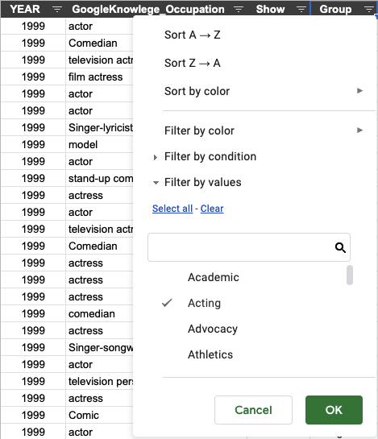

The syntax for filtering is as follows:

```r
# Single value
dataset %>% dplyr::filter(column_name == "value")

# Multiple values
dataset %>% dplyr::filter(column_name %in% c("value_1", "value_2"))

# Another example
dataset %>% dplyr::filter(column_name %in% c("value_1", 100, FALSE))
```

**Note:**

- Use `==` to filter for a specific (and exact) value
- Use `!=` to filter out (remove) a specific (and exact) value
- Use `%in%` to filter for multiple (and exact) values
  - The values of interest should be encapsulated in a `c()` function
  - Example: `c(1, 2, 3)` or `c("hello", "goodbye")`
- Add `!` in front of the column name to inverse the `%in%` filter (i.e. “not in”)
  - Example: `dplyr::filter(!column_name %in% c(1, 2))`

Further reading on [dplyr::filter](https://dplyr.tidyverse.org/reference/filter.html)

### Count

Lastly, after the `daily_show_guests` object is filtered, we pipe it to `dplyr::count()` function:

```r
  dplyr::count(year, group)
```

The end result is this dataset, which is assigned to `dsg_table` (see line 10):

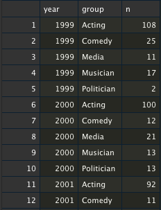

### Plot

Lines 14-30 use the `ggplot2` package to create a barplot for the `dsg_table` dataset that we created.

Notice that we are chaining together multiple functions, similar to what we were doing above. But instead of using `%>%`, we use `+` for `ggplot2`.

```r
ggplot2::ggplot(
  data = dsg_table,
  mapping = ggplot2::aes(x = as.factor(year), y = n, fill = group)
) +
  ggplot2::geom_col() +
  ggplot2::labs(title = "The Daily Show Guests", x = "Year", y = "Guests (n)") +
  ggplot2::theme(
    legend.position = "right",
    axis.text.x = ggplot2::element_text(angle = 90, vjust = 0.5, hjust = 1, size = 12)
  ) +
  ggplot2::ylim(0, 200) +
  ggplot2::scale_fill_brewer(palette = "Accent") +
  ggplot2::guides(
    color = "none",
    size = "none",
    fill = ggplot2::guide_legend(title = "Category")
  )
```

The `ggplot2` package has lots of features and tons of customization options, so we will cover it in another session.

As an example, the plot we saw in the “End-Goal” section can be reproduced with the first 5 lines of the code above (lines 14-18). Everything else (lines 19-30) is to customize the look and feel of the plot.

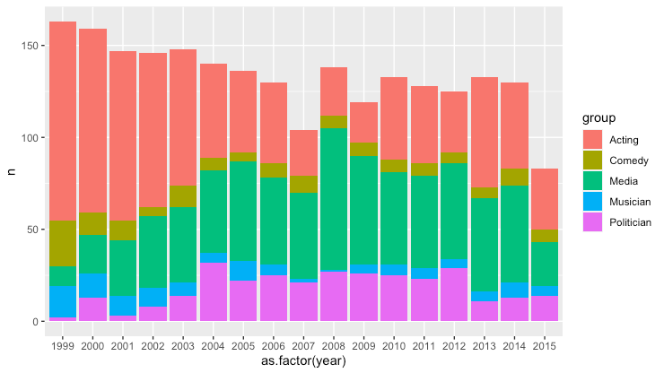

```r
ggplot2::ggplot(
  data = dsg_table,
  mapping = ggplot2::aes(x = as.factor(year), y = n, fill = group)
) +
  ggplot2::geom_col()
```

Further reading on [ggplot2](https://ggplot2-book.org/) and [R graphics](https://r-graphics.org/)